# Tracking Covid-19 in Connecticut

John Goldin

2020-06-19

## Latest Connecticut Data from the Department of Public Health

|  | Total Today | Change from Yesterday | Change from Week Ago |
| --- | --- | --- | --- |
| Cases | 45,440 | +11 | +979 |
| Deaths | 4,226 | +7 | +80 |
| Hospitalizations | 176 | -10 | -70 |
| Tests | 370,638 | +4,722 | +50,594 |
| — |  |  |  |
| Nursing home cases | 8,669 |  | +152 |
| Nursing home deaths | 2,647 |  | +105 |

PDF report from the Connecticut Deprtment of Public Health:[COVID-19 Update June 18, 2020](https://portal.ct.gov/-/media/Coronavirus/CTDPHCOVID19summary6182020.pdf)

Source: Multiple tables from [Connecticut Open Data](https://data.ct.gov/stories/s/COVID-19-data/wa3g-tfvc/)  
——-

A [post I created back in March](https://johngoldin.com/post/2020-03-29-covid19-cases-in-connecticut/) aimed to track the growth of Covid-19 as it hit Connecticut. Back then at the end of March I did not realize that the greater New York area (including Connecticut) would be the center of the first wave in the US. At that time what I was reading focused on the nature of exponential growth of an epidemic. We were urged to “flatten the curve” and that shaped the way I presented the data in that post. I have been updating the figures in that post each evening. During that time the [Connecticut data portal](https://data.ct.gov/stories/s/COVID-19-data/wa3g-tfvc/) has expanded considerably, and I’ve built [some R code](https://github.com/johngoldin/ctcorona/blob/master/R/daily_ct_stats.R) that let’s me easily update that post. I’ll use the same data infrastructure for this post as well. This post is much more oriented toward tracking the current status of the epidemic in Connecticut.

## Tracking the Virus in Connecticut

This post focuses on what is happening recently. The aim is to use the recent trend to get some idea of the near future. The first plot will show the average number of new cases reported each day along with a line that displays the rolling seven-day average. Typically there are day-of-the-week effects in the reporting so it’s best to focus on the seven-day average.

The plot shows the history of new cases and also shows the actions required by some of Governor Lamont’s executive orders.

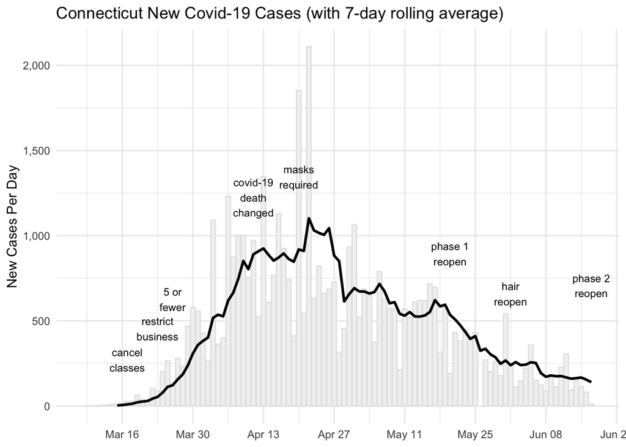

Figure 1: New Cases

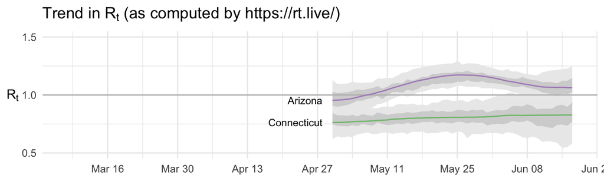

Figure 2: Estimated R<sub>t</sub>

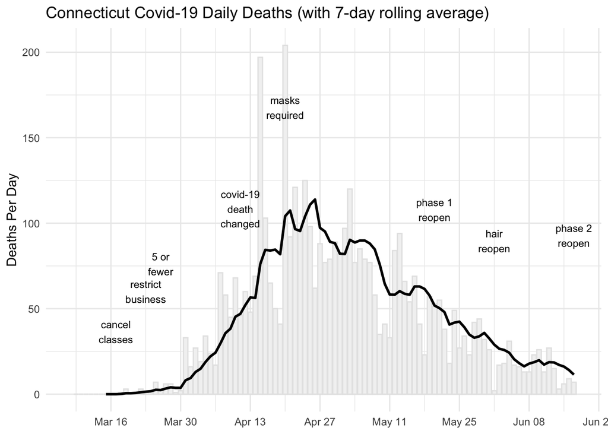

Figure 3: Daily Deaths

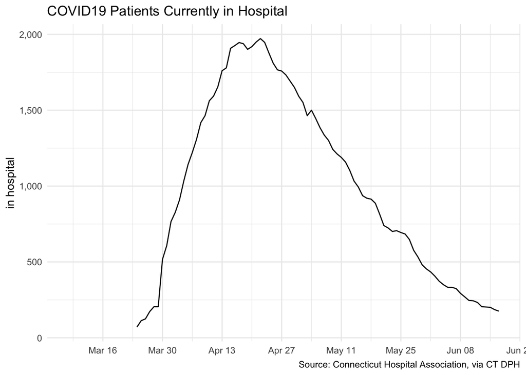

Figure 4: Hospitalizations for Covid-19

Note that as of June (and a month previous), Connecticut, New York, and New Jersey have among the lowest values for R<sub>t</sub> in the country. This is good news for us in Connecticut. I have included R<sub>t</sub> for Arizona as a contrast with a state that has lately shown [signs of a growing outbreak](https://www.fox10phoenix.com/news/arizona-medical-experts-alarmed-over-surge-in-covid-19-cases). The goal in Connecticut and in the entire New York City area is to keep R<sub>t</sub> well under 1. As of 2020-06-17 R<sub>t</sub> is 0.83. On the other hand, in Arizona R<sub>t</sub> is about 1.06.

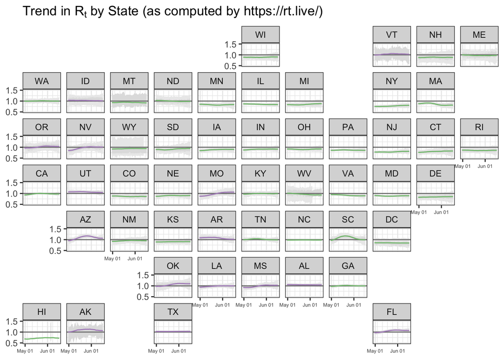

Figure 5: Estimate of R<sub>t</sub> by State

## Deaths by Age

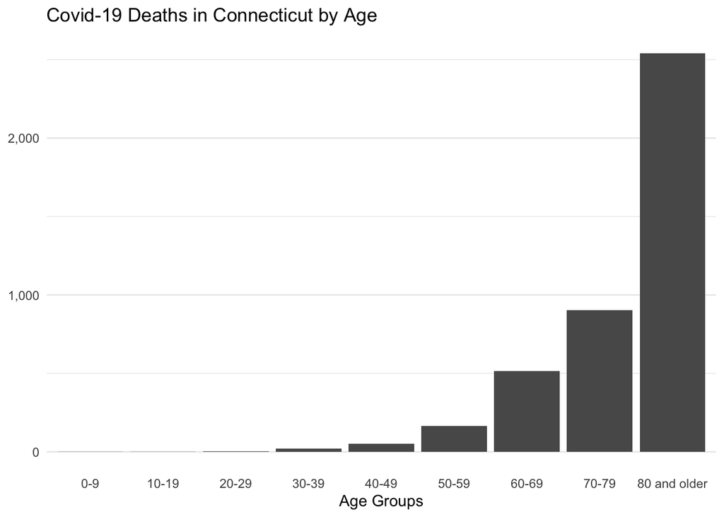

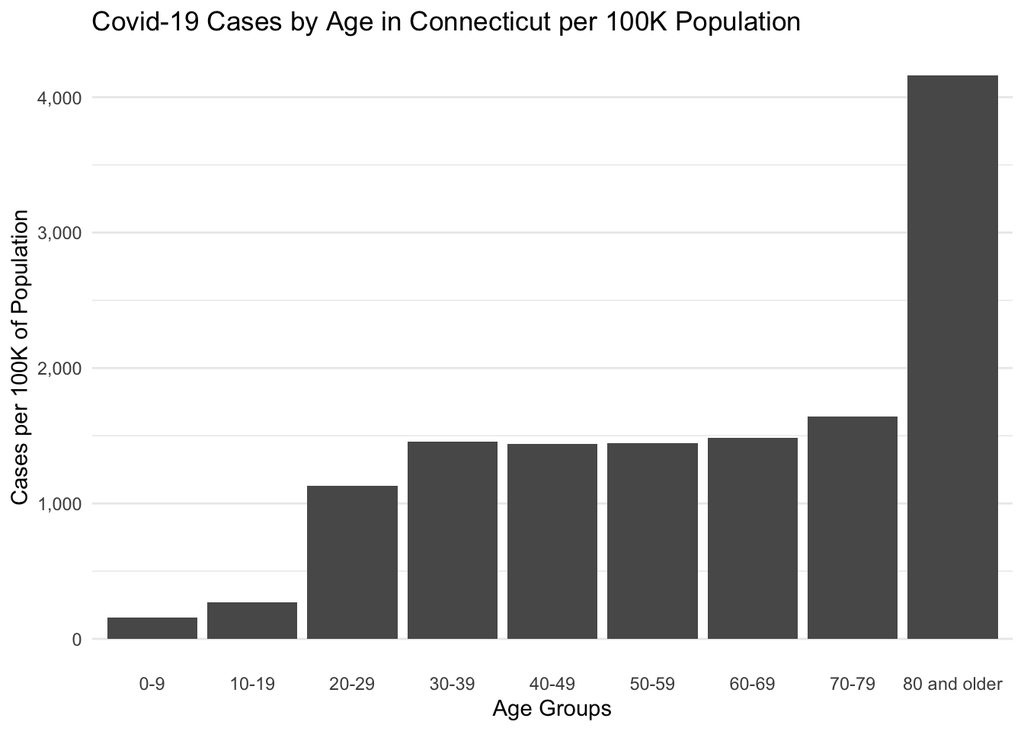

Figure 6: Relationship of Age to Covid-19 Deaths andCases

## Nursing Homes

Nursing homes have been hard hit by the epidemic. It’s hard to control coronavirus outbreak in a group living situation, which includes prisons and cruises ship. On top of that, Covid-19 is especially serious for the elderly. The combination in nursing homes has been deadly. There have been 2,647 deaths in Connecticut Nursing Homes which makes 62.6% of the total of 4,226 deaths from Covid-19.

## Variations by County in Connecticut

Connecticut is part of the epidemic’s surge in the New York area and the magnitude of the epidemic has been greater in the counties closer to New York City. Back in March cases first appeared in Fairfield County and then spread to Litchfield, New Haven, and Hartford. More recently Hartford has been the area that we have to watch and even the most eastern counties in the state.

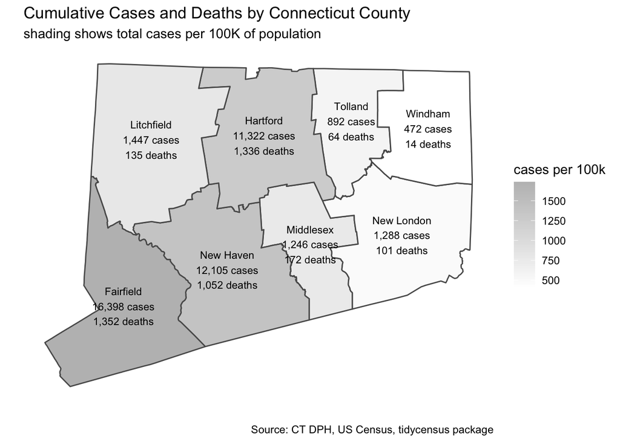

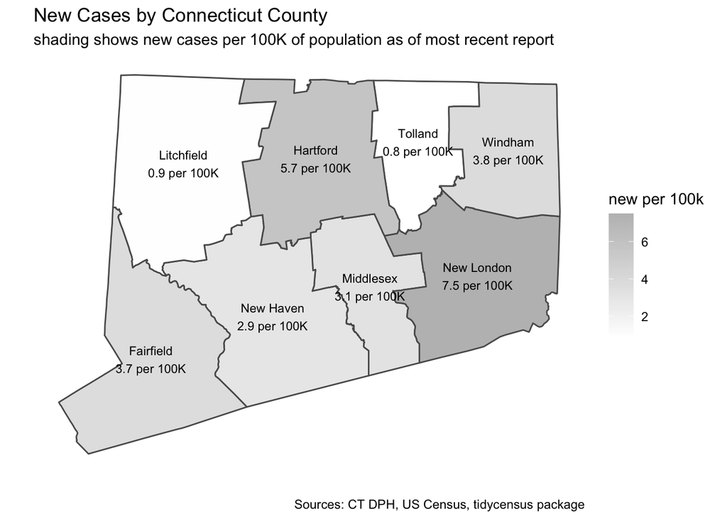

Figure 7: County Maps of New and of Cumulative Cases

### By County and Type of Town

There are 169 towns in Connecticut, which makes it hard to eamine variations by town. To help examine variations within counties, I’ll use a typology of towns called [The Five Connecticuts](https://ctdatahaven.org/sites/ctdatahaven/files/UConnCPR%20Changing%20Demographics-5%20CTs%202004.pdf) that divides towns into five categories based on census variables: Urban Core, Urban Periphery, Suburban, Rural, and a fifth category for Wealthy Suburbs used for some towns in Fairfield County. Adjusting for population, the number of cases has been greater in the counties closer to New York City. In the figure below I’ll fold the wealthy towns into the Suburban category. I have excluded Montville and Somers because the prisons in those towns complicates interpretation of the town statistics.

Counties are laid out from top to bottom and the counties closer to New York are toward the top. The columns show the four categories. Urban towns have been hit harder than suburban and rural towns. While density may have some effect on case rates, the report [Towards Health Equity in Connecticut: The Role of Social Inequality and the Impact of COVID-19](https://ctdatahaven.org/reports/towards-health-equity-connecticut) by DataHaven documents the unequal impact of the epidemic in Connecticut related to social inequality.

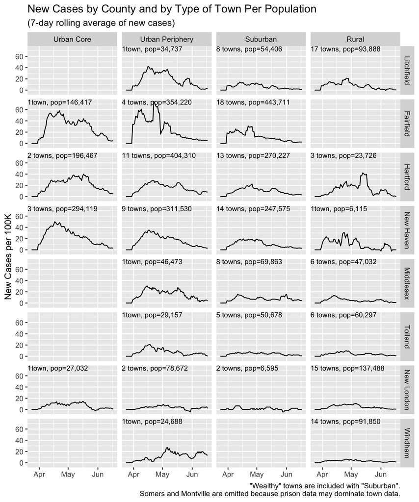

## Methodology and Sources

#### Counts from Connecticut Department of Public Health

The charts shows the counts of cases and deaths as they are reported by the Connecticut Department of Public Health. Reports sometimes end up in batches. There is a day of the week effect, with fewer cases on weekends. Some of the unusually large peaks and valleys in these charts are due to reporting process. The DPH has also begun producing reports based on the date a sample was taken for a test and for the date of death. That’s a more accurate way to look at the change over time, but it means the data for the most recent days are hard to interpret because some data may be “in process” and not yet reported. In these charts I have used “date of report” rather than “date of sample taken” or “date of death” because that gives me all of the recent data that is available and because that is what most other data projects (such as the Covid-19 Project or the New York Times) have been using.